# Aplicação prática: métodos locais e kernels

Material complementar — A2

# 1 Objetivo

Este material apresenta, de forma prática, um fluxo completo para os conceitos estudados em **métodos locais e kernels**:

**Fluxo de análise**

**Dados** → **treino/teste** → **validação cruzada** → **KNN** → **Nadaraya–Watson** → **regressão local** → **Kernel Ridge** → **avaliação final**

Este material serve de apoio para a realização da **Atividade Avaliativa A2**. O exemplo deve ser utilizado como referência para compreender a lógica dos procedimentos, a seleção dos hiperparâmetros e sua implementação em R.

A base utilizada aqui é **diferente da base da atividade avaliativa**.

O objetivo principal não é descobrir qual método é universalmente melhor, mas compreender como diferentes mecanismos de **localidade e suavização** controlam a flexibilidade do modelo.

# 2 Pacotes

```r
library(tidyverse)
library(tidymodels)
library(kknn)
library(KernSmooth)
library(locfit)

tidymodels_prefer()

set.seed(335)
```

# 3 Uma base simulada para estudo

Vamos construir uma relação não linear entre uma variável preditora $x$ e uma resposta $y$.

```r
set.seed(335)

n <- 300

x <- runif(n, -3, 3)

y <-
  2 * sin(1.5 * x) +
  0.45 * x +
  rnorm(n, mean = 0, sd = 0.65)

dados <-
  tibble(
    x = x,
    y = y
  )

glimpse(dados)
```

```
Rows: 300
Columns: 2
$ x <dbl> -2.0435146, -0.5887362, -1.1289438, -1.9602219, -2.7512300, -1.89844…
$ y <dbl> -1.94825260, -1.36509649, -1.87050899, -0.92553411, 0.01640305, -1.3…
```

Visualizamos os dados:

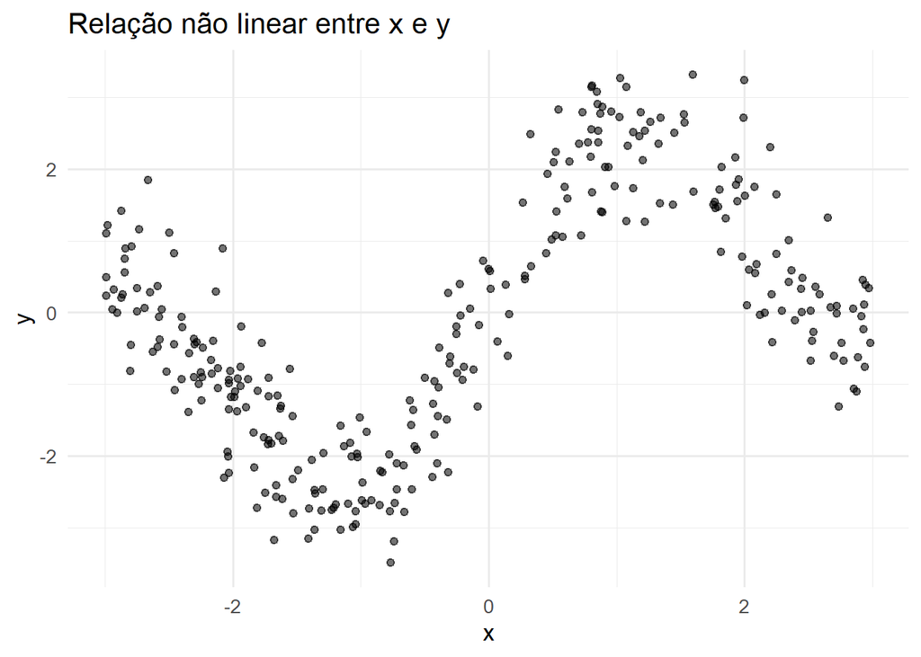

```r
ggplot(dados, aes(x = x, y = y)) +
  geom_point(alpha = 0.55) +
  labs(
    x = "x",
    y = "y",
    title = "Relação não linear entre x e y"
  ) +
  theme_minimal(base_size = 13)
```

A relação entre $x$ e $y$ é claramente não linear. Portanto, uma reta global pode ser excessivamente rígida para representar a estrutura dos dados.

Em uma aplicação real, naturalmente, não conhecemos a função que gerou os dados.

# 4 Treinamento, validação e teste

Assim como na Atividade 1, começamos reservando o conjunto de teste:

$$\mathcal D
=
\mathcal D_{\text{treino}}
\cup
\mathcal D_{\text{teste}}$$

```r
set.seed(335)

split <-
  initial_split(
    dados,
    prop = 0.80
  )

treino <- training(split)
teste  <- testing(split)

dim(treino)
```

```
[1] 240   2
```

```r
dim(teste)
```

```
[1] 60  2
```

**Importante**

O conjunto de **teste** será reservado exclusivamente para a **avaliação final do modelo**.

A escolha de $k$, $h$, $\lambda$ e dos demais hiperparâmetros será realizada por **validação cruzada aplicada apenas ao conjunto de treinamento**.

# 5 Validação cruzada

Criamos 10 partições dentro do conjunto de treinamento:

```r
set.seed(335)

folds <-
  vfold_cv(
    treino,
    v = 10
  )

folds
```

```
#  10-fold cross-validation
# A tibble: 10 × 2
   splits           id
   <list>           <chr>
 1 <split [216/24]> Fold01
 2 <split [216/24]> Fold02
 3 <split [216/24]> Fold03
 4 <split [216/24]> Fold04
 5 <split [216/24]> Fold05
 6 <split [216/24]> Fold06
 7 <split [216/24]> Fold07
 8 <split [216/24]> Fold08
 9 <split [216/24]> Fold09
10 <split [216/24]> Fold10
```

Em cada iteração, aproximadamente nove partes são utilizadas para ajuste e uma parte para validação.

A lógica continua sendo:

$$\text{Treino}
\rightarrow
\text{validação cruzada}
\rightarrow
\text{hiperparâmetro ótimo}$$

O teste permanece intocado.

# 6 Modelo de referência: regressão linear

Antes dos métodos locais, ajustamos uma regressão linear simples:

$$Y=\beta_0+\beta_1X+\varepsilon$$

```r
modelo_lm <-
  linear_reg() |>
  set_engine("lm")

wf_lm <-
  workflow() |>
  add_formula(y ~ x) |>
  add_model(modelo_lm)

ajuste_lm <-
  fit(
    wf_lm,
    data = treino
  )
```

Visualizamos o ajuste:

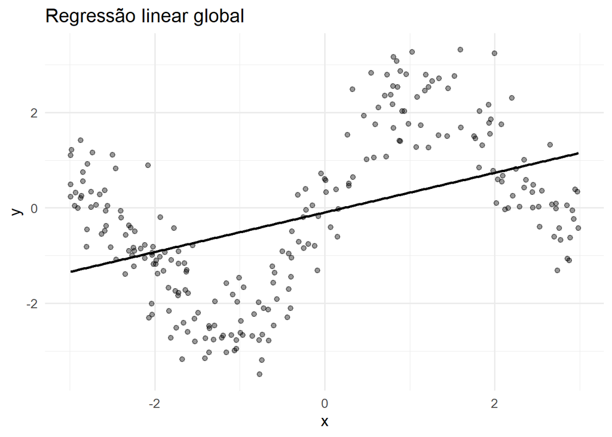

```r
grid_x <-
  tibble(
    x = seq(
      min(treino$x),
      max(treino$x),
      length.out = 300
    )
  )

pred_lm <-
  predict(
    ajuste_lm,
    new_data = grid_x
  ) |>
  bind_cols(grid_x)

ggplot(treino, aes(x = x, y = y)) +
  geom_point(alpha = 0.4) +
  geom_line(
    data = pred_lm,
    aes(y = .pred),
    linewidth = 1
  ) +
  labs(
    title = "Regressão linear global",
    x = "x",
    y = "y"
  ) +
  theme_minimal(base_size = 13)
```

A dificuldade é visual: uma única reta tenta representar toda a relação entre $x$ e $y$.

Os métodos locais seguirão outra estratégia.

# 7 KNN para regressão

Para prever em $x_0$, o KNN identifica os $k$ pontos mais próximos:

$$N_k(x_0)
=
\{\text{$k$ vizinhos mais próximos de }x_0\}$$

e calcula

$$\widehat g(x_0)
=
\frac{1}{k}
\sum_{i\in N_k(x_0)}Y_i$$

Assim, a previsão é uma média local.

## 7.1 KNN como regressão local de grau zero

Considere o problema

$$\widehat\beta_0(x_0)
=
\arg\min_{\beta_0}
\sum_{i\in N_k(x_0)}
(Y_i-\beta_0)^2$$

Derivando:

$$\frac{\partial}{\partial\beta_0}
\sum_{i\in N_k(x_0)}
(Y_i-\beta_0)^2
=
-2
\sum_{i\in N_k(x_0)}
(Y_i-\beta_0)$$

Igualando a zero:

$$\widehat\beta_0(x_0)
=
\frac{1}{k}
\sum_{i\in N_k(x_0)}Y_i$$

Portanto,

$$\boxed{
\widehat g_{\text{KNN}}(x_0)
=
\widehat\beta_0(x_0)
}$$

O KNN pode ser interpretado como uma **regressão local constante**, ou regressão local de grau zero.

A palavra **local** é essencial: uma nova constante é obtida para cada ponto $x_0$.

# 8 Ajustando KNN com tidymodels

No `parsnip`, utilizamos `nearest_neighbor()`.

```r
modelo_knn <-
  nearest_neighbor(
    neighbors = tune(),
    weight_func = "rectangular",
    dist_power = 2
  ) |>
  set_mode("regression") |>
  set_engine("kknn")
```

Construímos a receita:

```r
receita_knn <-
  recipe(y ~ x, data = treino) |>
  step_normalize(all_predictors())
```

Mesmo com apenas uma variável, manteremos a padronização para que o procedimento possa ser generalizado para várias covariáveis.

```r
wf_knn <-
  workflow() |>
  add_recipe(receita_knn) |>
  add_model(modelo_knn)
```

# 9 Construindo a grade de $k$

Investigamos diferentes tamanhos de vizinhança:

```r
grade_k <-
  tibble(
    neighbors = seq(1, 61, by = 2)
  )

grade_k
```

```
# A tibble: 31 × 1
   neighbors
       <dbl>
 1         1
 2         3
 3         5
 4         7
 5         9
 6        11
 7        13
 8        15
 9        17
10        19
# ℹ 21 more rows
```

Valores pequenos de $k$ produzem vizinhanças muito locais.

Valores grandes utilizam uma parcela maior dos dados.

Esquematicamente,

$$k\downarrow
\quad\Longrightarrow\quad
\text{localidade}\uparrow
\quad\Longrightarrow\quad
\text{flexibilidade}\uparrow$$

enquanto

$$k\uparrow
\quad\Longrightarrow\quad
\text{suavização}\uparrow
\quad\Longrightarrow\quad
\text{flexibilidade}\downarrow$$

# 10 Selecionando $k$ por validação cruzada

```r
set.seed(335)

tuning_knn <-
  tune_grid(
    wf_knn,
    resamples = folds,
    grid = grade_k,
    metrics = metric_set(rmse),
    control = control_grid(save_pred = TRUE)
  )
```

Extraímos os resultados:

```r
resultados_knn <-
  collect_metrics(tuning_knn) |>
  filter(.metric == "rmse")

resultados_knn |>
  select(neighbors, mean, std_err) |>
  arrange(neighbors)
```

```
# A tibble: 31 × 3
   neighbors  mean std_err
       <dbl> <dbl>   <dbl>
 1         1 0.919  0.0450
 2         3 0.748  0.0289
 3         5 0.701  0.0253
 4         7 0.680  0.0274
 5         9 0.676  0.0266
 6        11 0.674  0.0264
 7        13 0.671  0.0275
 8        15 0.670  0.0259
 9        17 0.665  0.0257
10        19 0.658  0.0285
# ℹ 21 more rows
```

Selecionamos o menor RMSE médio:

```r
melhor_knn <-
  select_best(
    tuning_knn,
    metric = "rmse"
  )

melhor_knn
```

```
# A tibble: 1 × 2
  neighbors .config
      <dbl> <chr>
1        21 pre0_mod11_post0
```

O ponto fundamental é:

$$\boxed{
k^\ast
=
\arg\min_k
\widehat R_{CV}(k)
}$$

O conjunto de teste ainda não foi utilizado.

# 11 Curva do erro de validação do KNN

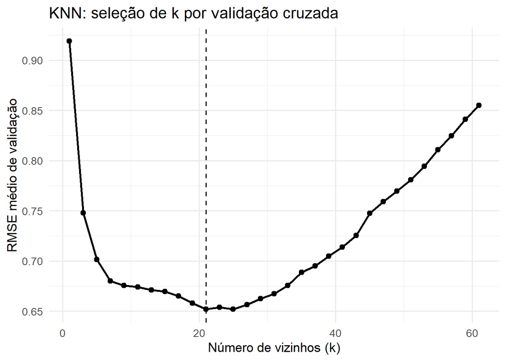

```r
ggplot(
  resultados_knn,
  aes(x = neighbors, y = mean)
) +
  geom_line(linewidth = 1) +
  geom_point(size = 2) +
  geom_vline(
    xintercept = melhor_knn$neighbors,
    linetype = 2
  ) +
  labs(
    x = "Número de vizinhos (k)",
    y = "RMSE médio de validação",
    title = "KNN: seleção de k por validação cruzada"
  ) +
  theme_minimal(base_size = 13)
```

## 11.1 Como interpretar?

Com $k$ muito pequeno, o modelo pode acompanhar excessivamente particularidades da amostra.

Isso tende a produzir

$$\text{baixo viés}
\qquad\text{e}\qquad
\text{alta variância}$$

Com $k$ muito grande, muitas observações distantes influenciam a previsão.

O modelo se torna mais suave:

$$\text{maior viés}
\qquad\text{e}\qquad
\text{menor variância}$$

A validação cruzada procura um compromisso entre esses dois extremos.

# 12 Visualizando diferentes valores de $k$

Vamos comparar três níveis de flexibilidade.

```r
ajustar_knn <- function(k) {

  modelo <-
    nearest_neighbor(
      neighbors = k,
      weight_func = "rectangular",
      dist_power = 2
    ) |>
    set_mode("regression") |>
    set_engine("kknn")

  workflow() |>
    add_recipe(receita_knn) |>
    add_model(modelo) |>
    fit(data = treino)
}

k_pequeno <- 3
k_otimo   <- melhor_knn$neighbors
k_grande  <- 51

fit_k3  <- ajustar_knn(k_pequeno)
fit_kcv <- ajustar_knn(k_otimo)
fit_k51 <- ajustar_knn(k_grande)
```

Previsões em uma grade:

```r
pred_k <-
  bind_rows(
    predict(fit_k3, grid_x) |>
      bind_cols(grid_x) |>
      mutate(modelo = paste0("k = ", k_pequeno)),

    predict(fit_kcv, grid_x) |>
      bind_cols(grid_x) |>
      mutate(modelo = paste0("k = ", k_otimo, " (CV)")),

    predict(fit_k51, grid_x) |>
      bind_cols(grid_x) |>
      mutate(modelo = paste0("k = ", k_grande))
  )
```

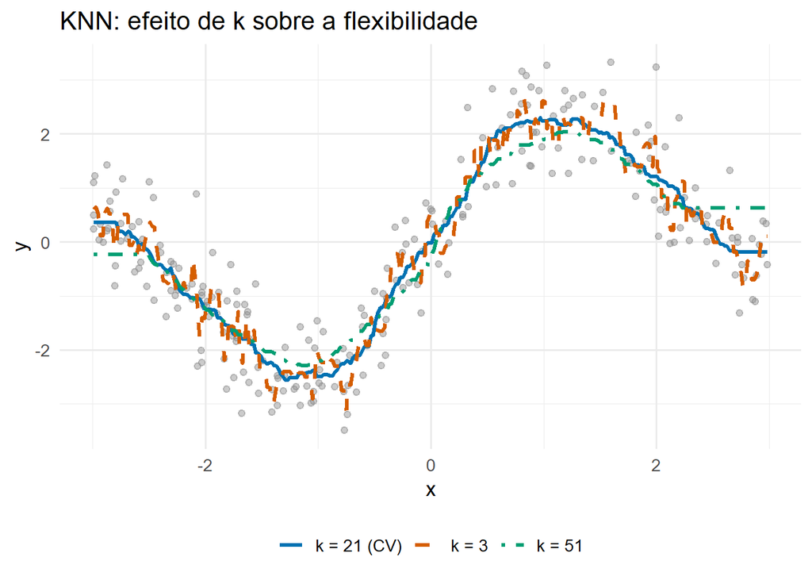

```r
# Rótulos dos modelos
rot_pequeno <- paste0("k = ", k_pequeno)
rot_otimo   <- paste0("k = ", k_otimo, " (CV)")
rot_grande  <- paste0("k = ", k_grande)

# Cores
cores_k <- setNames(
  c("#D55E00", "#0072B2", "#009E73"),
  c(rot_pequeno, rot_otimo, rot_grande)
)

# Tipos de linha
linhas_k <- setNames(
  c("dashed", "solid", "dotdash"),
  c(rot_pequeno, rot_otimo, rot_grande)
)

ggplot(treino, aes(x = x, y = y)) +
  geom_point(
    alpha = 0.45,
    color = "grey55"
  ) +
  geom_line(
    data = pred_k,
    aes(
      y = .pred,
      color = modelo,
      linetype = modelo
    ),
    linewidth = 1.2
  ) +
  scale_color_manual(values = cores_k) +
  scale_linetype_manual(values = linhas_k) +
  labs(
    x = "x",
    y = "y",
    color = NULL,
    linetype = NULL,
    title = "KNN: efeito de k sobre a flexibilidade"
  ) +
  theme_minimal(base_size = 13) +
  theme(
    legend.position = "bottom"
  )
```

Observe que $k$ não é apenas um detalhe computacional. Ele controla diretamente a complexidade do estimador.

# 13 Do KNN aos kernels

No KNN uniforme, podemos escrever os pesos aproximadamente como

$$w_i(x_0)
=
\begin{cases}
1/k, & X_i\in N_k(x_0)\\
0, & \text{caso contrário}
\end{cases}$$

Todos os $k$ vizinhos recebem o mesmo peso.

Isso cria uma fronteira rígida:

$$\text{vizinho}
\quad\text{versus}\quad
\text{não vizinho}$$

Uma alternativa é permitir que a influência de uma observação diminua gradualmente com sua distância a $x_0$.

É exatamente essa a ideia dos **kernels de suavização**.

# 14 Estimador de Nadaraya–Watson

O estimador pode ser escrito como

$$\widehat g_h(x_0)
=
\frac{
\sum_{i=1}^{n}
K\left(
\frac{X_i-x_0}{h}
\right)Y_i
}{
\sum_{i=1}^{n}
K\left(
\frac{X_i-x_0}{h}
\right)
}$$

ou, equivalentemente,

$$\widehat g_h(x_0)
=
\sum_{i=1}^{n}
w_i(x_0)Y_i$$

com

$$w_i(x_0)
=
\frac{
K\left(
\frac{X_i-x_0}{h}
\right)
}{
\sum_{j=1}^{n}
K\left(
\frac{X_j-x_0}{h}
\right)
}$$

Os pesos dependem da distância ao ponto em que queremos realizar a previsão.

# 15 Kernel Gaussiano

Considere

$$K(u)
=
\frac{1}{\sqrt{2\pi}}
\exp\left(-\frac{u^2}{2}\right)$$

Implementamos o estimador:

```r
nw_gauss <- function(x_train, y_train, x_new, h) {

  map_dbl(
    x_new,
    function(x0) {

      pesos <-
        dnorm(
          (x_train - x0) / h
        )

      sum(pesos * y_train) /
        sum(pesos)
    }
  )
}
```

Exemplo com $h=0.30$:

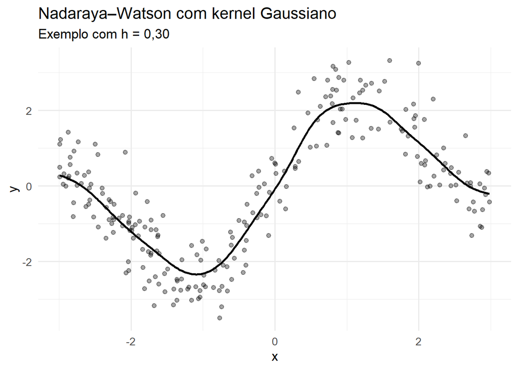

```r
pred_nw_exemplo <-
  grid_x |>
  mutate(
    .pred = nw_gauss(
      treino$x,
      treino$y,
      x,
      h = 0.30
    )
  )

ggplot(treino, aes(x = x, y = y)) +
  geom_point(alpha = 0.35) +
  geom_line(
    data = pred_nw_exemplo,
    aes(y = .pred),
    linewidth = 1
  ) +
  labs(
    title = "Nadaraya–Watson com kernel Gaussiano",
    subtitle = "Exemplo com h = 0,30",
    x = "x",
    y = "y"
  ) +
  theme_minimal(base_size = 13)
```

# 16 O papel da largura de banda $h$

No estimador kernel, $h$ controla o tamanho efetivo da vizinhança.

Quando

$$h\downarrow$$

os pesos se concentram fortemente em observações próximas de $x_0$.

Assim,

$$h\downarrow
\quad\Longrightarrow\quad
\text{localidade}\uparrow
\quad\Longrightarrow\quad
\text{flexibilidade}\uparrow$$

Por outro lado,

$$h\uparrow
\quad\Longrightarrow\quad
\text{suavização}\uparrow
\quad\Longrightarrow\quad
\text{flexibilidade}\downarrow$$

**Comparação com KNN**

$$k\downarrow
\Rightarrow
\text{flexibilidade}\uparrow$$

mas

$$h\downarrow
\Rightarrow
\text{flexibilidade}\uparrow$$

Logo, **aumentar $k$ suaviza**, enquanto **aumentar $h$ também suaviza**.

# 17 Selecionando $h$ por validação cruzada

Como nossa implementação de Nadaraya–Watson é direta, podemos escrever uma função para avaliar cada $h$ nos folds.

```r
rmse_nw_fold <- function(split, h) {

  dados_ajuste <- analysis(split)
  dados_val    <- assessment(split)

  pred <-
    nw_gauss(
      dados_ajuste$x,
      dados_ajuste$y,
      dados_val$x,
      h
    )

  sqrt(
    mean(
      (dados_val$y - pred)^2
    )
  )
}
```

Construímos uma grade:

```r
grade_h <-
  tibble(
    h = seq(0.05, 1.20, length.out = 35)
  )
```

Calculamos o RMSE médio de validação:

```r
resultados_h <-
  grade_h |>
  mutate(
    rmse_cv = map_dbl(
      h,
      function(h_atual) {

        map_dbl(
          folds$splits,
          rmse_nw_fold,
          h = h_atual
        ) |>
          mean()
      }
    )
  )

resultados_h
```

```
# A tibble: 35 × 2
        h rmse_cv
    <dbl>   <dbl>
 1 0.05     0.701
 2 0.0838   0.671
 3 0.118    0.662
 4 0.151    0.657
 5 0.185    0.654
 6 0.219    0.654
 7 0.253    0.656
 8 0.287    0.660
 9 0.321    0.665
10 0.354    0.673
# ℹ 25 more rows
```

Selecionamos

```r
melhor_h <-
  resultados_h |>
  slice_min(
    rmse_cv,
    n = 1
  )

melhor_h
```

```
# A tibble: 1 × 2
      h rmse_cv
  <dbl>   <dbl>
1 0.219   0.654
```

Portanto,

$$\boxed{
h^\ast
=
\arg\min_h
\widehat R_{CV}(h)
}$$

Novamente, o conjunto de teste não participou da escolha.

# 18 Curva do erro de validação em função de $h$

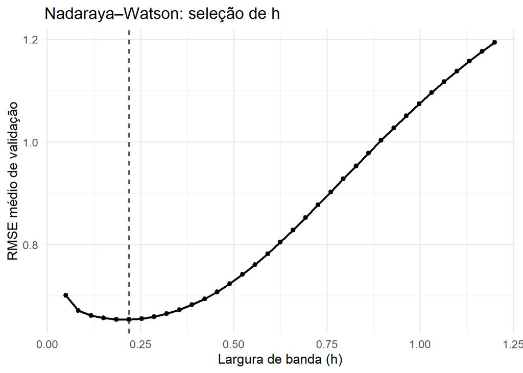

```r
ggplot(
  resultados_h,
  aes(x = h, y = rmse_cv)
) +
  geom_line(linewidth = 1) +
  geom_point(size = 1.8) +
  geom_vline(
    xintercept = melhor_h$h,
    linetype = 2
  ) +
  labs(
    x = "Largura de banda (h)",
    y = "RMSE médio de validação",
    title = "Nadaraya–Watson: seleção de h"
  ) +
  theme_minimal(base_size = 13)
```

Valores muito pequenos de $h$ podem gerar um ajuste excessivamente variável.

Valores muito grandes podem suavizar a estrutura dos dados em excesso.

# 19 Visualizando diferentes valores de $h$

```r
h_pequeno <- 0.08
h_otimo   <- melhor_h$h
h_grande  <- 0.90

pred_h <-
  bind_rows(
    grid_x |>
      mutate(
        .pred = nw_gauss(
          treino$x, treino$y, x, h_pequeno
        ),
        modelo = paste0("h = ", h_pequeno)
      ),

    grid_x |>
      mutate(
        .pred = nw_gauss(
          treino$x, treino$y, x, h_otimo
        ),
        modelo = paste0("h = ", round(h_otimo, 3), " (CV)")
      ),

    grid_x |>
      mutate(
        .pred = nw_gauss(
          treino$x, treino$y, x, h_grande
        ),
        modelo = paste0("h = ", h_grande)
      )
  )
```

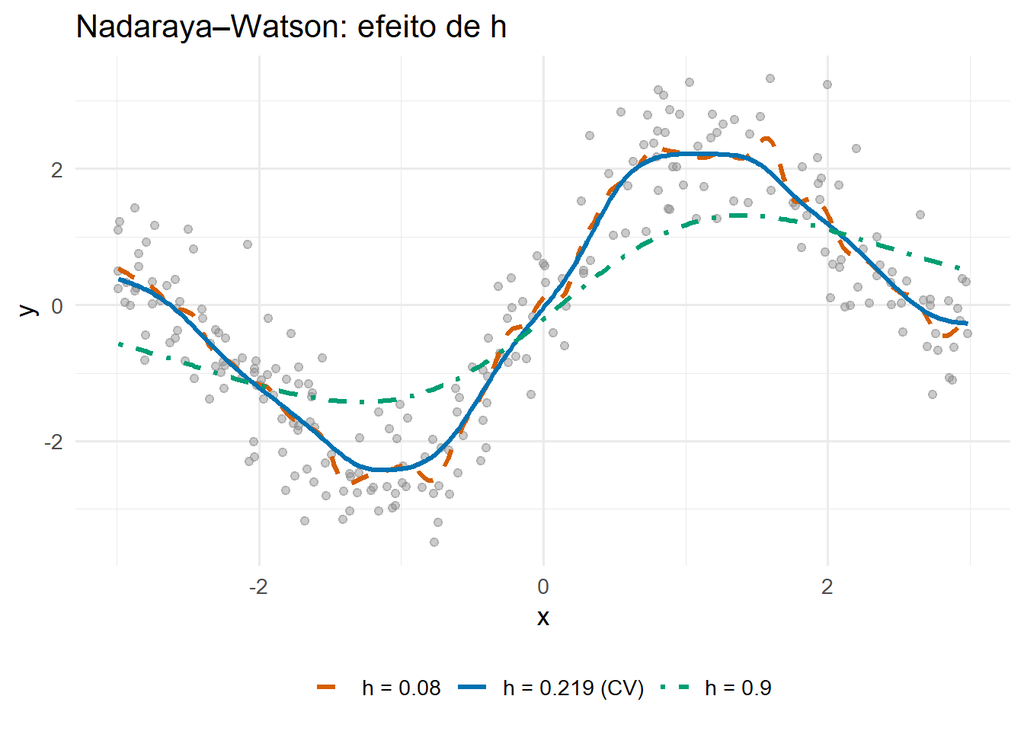

```r
# Rótulos dos modelos
rot_h_pequeno <- paste0("h = ", h_pequeno)
rot_h_otimo   <- paste0("h = ", round(h_otimo, 3), " (CV)")
rot_h_grande  <- paste0("h = ", h_grande)

# Cores:
# laranja = mais flexível
# azul    = selecionado por CV
# verde   = mais suavizado
cores_h <- setNames(
  c("#D55E00", "#0072B2", "#009E73"),
  c(rot_h_pequeno, rot_h_otimo, rot_h_grande)
)

# Tipos de linha
linhas_h <- setNames(
  c("dashed", "solid", "dotdash"),
  c(rot_h_pequeno, rot_h_otimo, rot_h_grande)
)

ggplot(treino, aes(x = x, y = y)) +
  geom_point(
    alpha = 0.45,
    color = "grey55"
  ) +
  geom_line(
    data = pred_h,
    aes(
      y = .pred,
      color = modelo,
      linetype = modelo
    ),
    linewidth = 1.2
  ) +
  scale_color_manual(values = cores_h) +
  scale_linetype_manual(values = linhas_h) +
  labs(
    x = "x",
    y = "y",
    color = NULL,
    linetype = NULL,
    title = "Nadaraya–Watson: efeito de h"
  ) +
  theme_minimal(base_size = 13) +
  theme(
    legend.position = "bottom"
  )
```

A comparação torna visível o compromisso entre viés e variância.

# 20 A forma do kernel

A largura de banda não é a única escolha possível. Também podemos modificar a forma de $K$.

Por exemplo, o kernel Epanechnikov é

$$K(u)
=
\frac{3}{4}(1-u^2)
I(|u|\leq 1)$$

Implementamos:

```r
K_epan <- function(u) {

  ifelse(
    abs(u) <= 1,
    0.75 * (1 - u^2),
    0
  )
}

nw_epan <- function(x_train, y_train, x_new, h) {

  map_dbl(
    x_new,
    function(x0) {

      pesos <-
        K_epan(
          (x_train - x0) / h
        )

      if (sum(pesos) == 0) {
        return(
          y_train[
            which.min(
              abs(x_train - x0)
            )
          ]
        )
      }

      sum(pesos * y_train) /
        sum(pesos)
    }
  )
}
```

Podemos comparar os kernels utilizando uma mesma largura de banda apenas para compreender visualmente a diferença:

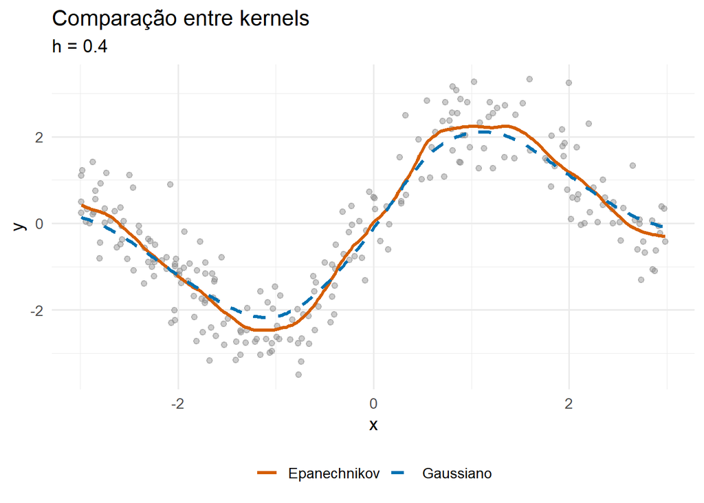

```r
h_comparacao <- 0.40

comparacao_kernel <-
  bind_rows(
    grid_x |>
      mutate(
        .pred = nw_gauss(
          treino$x,
          treino$y,
          x,
          h_comparacao
        ),
        kernel = "Gaussiano"
      ),

    grid_x |>
      mutate(
        .pred = nw_epan(
          treino$x,
          treino$y,
          x,
          h_comparacao
        ),
        kernel = "Epanechnikov"
      )
  )

# Cores dos kernels
cores_kernel <- c(
  "Epanechnikov" = "#D55E00",
  "Gaussiano"    = "#0072B2"
)

# Tipos de linha
linhas_kernel <- c(
  "Epanechnikov" = "solid",
  "Gaussiano"    = "dashed"
)

ggplot(treino, aes(x = x, y = y)) +
  geom_point(
    alpha = 0.45,
    color = "grey55"
  ) +
  geom_line(
    data = comparacao_kernel,
    aes(
      y = .pred,
      color = kernel,
      linetype = kernel
    ),
    linewidth = 1.2
  ) +
  scale_color_manual(values = cores_kernel) +
  scale_linetype_manual(values = linhas_kernel) +
  labs(
    title = "Comparação entre kernels",
    subtitle = paste0("h = ", h_comparacao),
    x = "x",
    y = "y",
    color = NULL,
    linetype = NULL
  ) +
  theme_minimal(base_size = 13) +
  theme(
    legend.position = "bottom"
  )
```

**Atenção**

- Para uma mesma largura de banda, os kernels **Gaussiano** e **Epanechnikov** produzem ajustes bastante semelhantes.
- Neste exemplo, a **largura de banda $h$ exerce um efeito muito mais evidente sobre a flexibilidade do estimador do que a escolha da forma do kernel**.
- Isso sugere que, na prática, a seleção adequada de $h$ costuma ser mais importante do que pequenas diferenças entre kernels razoáveis.
- Usar o mesmo valor numérico de $h$ é útil para uma comparação didática das formas dos kernels, mas não significa que esse valor seja ótimo para ambos.
- Em uma análise preditiva, cada procedimento deve ter seus hiperparâmetros selecionados adequadamente por validação.

# 21 Regressão polinomial local (LOESS)

Nadaraya–Watson pode ser interpretado como um ajuste local constante.

Uma extensão natural é permitir uma reta diferente em torno de cada ponto $x_0$:

$$Y_i
\approx
\beta_0(x_0)
+
\beta_1(x_0)(X_i-x_0)$$

Os parâmetros são obtidos resolvendo

$$\min_{\beta_0,\beta_1}
\sum_{i=1}^{n}
K\left(
\frac{X_i-x_0}{h}
\right)
\left[
Y_i-\beta_0-\beta_1(X_i-x_0)
\right]^2$$

A estimativa no ponto $x_0$ é

$$\widehat g(x_0)
=
\widehat\beta_0(x_0)$$

## Grau zero versus grau um

Usaremos `locfit()` para visualizar os dois casos.

```r
fit_local_0 <-
  locfit(
    y ~ lp(x, deg = 0, nn = 0.25),
    data = treino
  )

fit_local_1 <-
  locfit(
    y ~ lp(x, deg = 1, nn = 0.25),
    data = treino
  )
```

Previsões:

```r
pred_local <-
  bind_rows(
    grid_x |>
      mutate(
        .pred = predict(
          fit_local_0,
          newdata = grid_x
        ),
        grau = "Grau 0"
      ),

    grid_x |>
      mutate(
        .pred = predict(
          fit_local_1,
          newdata = grid_x
        ),
        grau = "Grau 1"
      )
  )
```

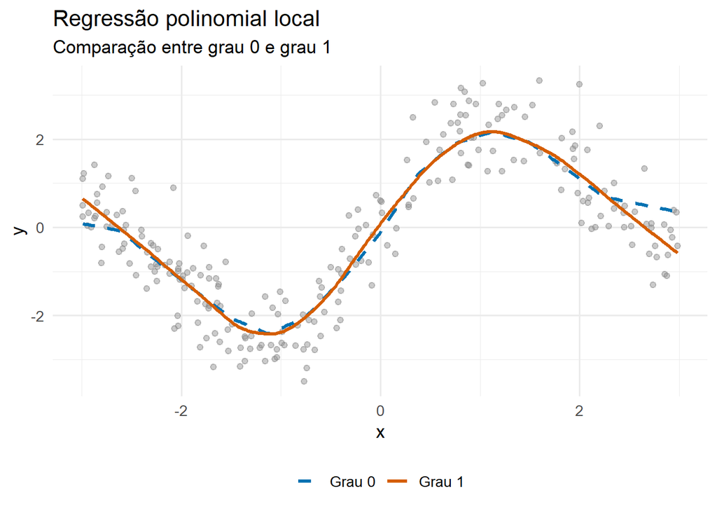

```r
# Cores
cores_grau <- c(
  "Grau 0" = "#0072B2",
  "Grau 1" = "#D55E00"
)

# Tipos de linha
linhas_grau <- c(
  "Grau 0" = "dashed",
  "Grau 1" = "solid"
)

ggplot(treino, aes(x = x, y = y)) +
  geom_point(
    alpha = 0.45,
    color = "grey55"
  ) +
  geom_line(
    data = pred_local,
    aes(
      y = .pred,
      color = grau,
      linetype = grau
    ),
    linewidth = 1.2
  ) +
  scale_color_manual(values = cores_grau) +
  scale_linetype_manual(values = linhas_grau) +
  labs(
    title = "Regressão polinomial local",
    subtitle = "Comparação entre grau 0 e grau 1",
    x = "x",
    y = "y",
    color = NULL,
    linetype = NULL
  ) +
  theme_minimal(base_size = 13) +
  theme(
    legend.position = "bottom"
  )
```

Uma vantagem importante do ajuste linear local aparece nas fronteiras.

Perto de uma extremidade do domínio, as observações disponíveis tendem a se concentrar de apenas um lado de $x_0$.

O ajuste constante local pode sofrer maior viés nessa situação.

A inclinação adicional do modelo de grau 1 permite compensar parte dessa assimetria.

# 22 Três visões de uma mesma ideia

KNN, Nadaraya–Watson e regressão polinomial local compartilham um princípio:

$$\text{usar principalmente informação próxima de }x_0$$

Mas fazem isso de formas diferentes.

| Método | Vizinhança/pesos | Ajuste local |
| --- | --- | --- |
| KNN | $k$ vizinhos | constante |
| Nadaraya–Watson | pesos kernel | constante |
| Polinomial local | pesos kernel | polinômio |

Assim,

$$\text{KNN}
\rightarrow
\text{vizinhança discreta}$$

$$\text{Nadaraya--Watson}
\rightarrow
\text{vizinhança ponderada}$$

$$\text{Regressão local}
\rightarrow
\text{vizinhança ponderada + estrutura local}$$

## Observação

Até aqui usamos apenas uma variável.

Suponha agora que existam $p$ preditores e que a distância Euclidiana seja

$$d(\mathbf x_i,\mathbf x_0)
=
\sqrt{
\sum_{j=1}^{p}
(x_{ij}-x_{0j})^2
}$$

À medida que $p$ cresce, manter pontos realmente próximos de $\mathbf x_0$ torna-se mais difícil.

O espaço se torna progressivamente mais esparso.

Esse fenômeno está associado à **maldição da dimensionalidade**.

Em métodos baseados em distância, adicionar uma variável pouco informativa pode alterar quem são os vizinhos sem fornecer sinal útil para prever $Y$.

Portanto,

$$\text{mais variáveis}
\not\Rightarrow
\text{melhores vizinhanças}$$

# 23 Métodos de kernel

Até agora, o kernel foi utilizado para definir **pesos locais**. Em métodos de kernel, a mesma ideia de similaridade também pode ser usada para construir modelos em espaços de funções potencialmente muito ricos.

Considere um kernel

$$K(\mathbf x,\mathbf x')$$

que mede similaridade entre duas observações. Um exemplo importante é o kernel Gaussiano/RBF:

$$K_\gamma(\mathbf x,\mathbf x')
=
\exp\left\{
-\gamma\|\mathbf x-\mathbf x'\|^2
\right\}$$

O parâmetro $\gamma$ controla a **escala de similaridade**:

$$\gamma\uparrow
\quad\Longrightarrow\quad
\text{similaridade cai mais rapidamente com a distância}$$

$$\gamma\downarrow
\quad\Longrightarrow\quad
\text{similaridade permanece alta em distâncias maiores}$$

Observe que esse papel não é o mesmo de $\lambda$, que aparecerá como parâmetro de regularização.

## Kernel Ridge Regression

Na regressão Ridge estudada na Atividade 1,

$$\widehat{\boldsymbol\beta}
=
\arg\min_{\boldsymbol\beta}
\left\{
\sum_{i=1}^{n}
(y_i-\mathbf x_i^\top\boldsymbol\beta)^2
+
\lambda\|\boldsymbol\beta\|_2^2
\right\}$$

A penalização atua diretamente sobre os coeficientes.

Em Kernel Ridge, procuramos uma função $f$ pertencente a um espaço de Hilbert com núcleo reprodutor $\mathcal H$:

$$\widehat f
=
\arg\min_{f\in\mathcal H}
\left\{
\sum_{i=1}^{n}
(y_i-f(x_i))^2
+
\lambda\|f\|_{\mathcal H}^2
\right\}$$

O primeiro termo mede o ajuste aos dados:

$$\underbrace{
\sum_{i=1}^{n}(y_i-f(x_i))^2
}_{\text{erro de treinamento}}$$

O segundo controla a complexidade da função:

$$\underbrace{
\lambda\|f\|_{\mathcal H}^2
}_{\text{regularização}}$$

Assim,

$$\text{Ridge}
\rightarrow
\text{penaliza }\boldsymbol\beta$$

enquanto

$$\text{Kernel Ridge}
\rightarrow
\text{penaliza a complexidade de }f$$

**Convenção usada neste material**

Utilizamos a função objetivo **sem** o fator $1/n$ diante da soma dos quadrados. Com essa convenção, a solução matricial contém $\mathbf K+\lambda\mathbf I$.

Se a função objetivo fosse escrita com $\frac{1}{n}\sum_i(\cdot)^2$, a solução equivalente conteria $\mathbf K+n\lambda\mathbf I$. Portanto, é importante manter a parametrização teórica e a implementação coerentes.

### Teorema do Representante e matriz de Gram

O Teorema do Representante garante que a solução pode ser escrita como

$$\widehat f(x)
=
\sum_{i=1}^{n}
\alpha_i K(x_i,x)$$

Mesmo que $\mathcal H$ seja um espaço de funções de dimensão muito grande — ou infinita — o estimador é determinado por apenas $n$ coeficientes:

$$\boldsymbol\alpha
=
(\alpha_1,\ldots,\alpha_n)^\top$$

Definimos a **matriz de Gram**

$$\mathbf K
=
\begin{bmatrix}
K(x_1,x_1) & \cdots & K(x_1,x_n)\\
\vdots & \ddots & \vdots\\
K(x_n,x_1) & \cdots & K(x_n,x_n)
\end{bmatrix}$$

Como

$$f(\mathbf X)=\mathbf K\boldsymbol\alpha$$

e

$$\|f\|_{\mathcal H}^2
=
\boldsymbol\alpha^\top
\mathbf K
\boldsymbol\alpha,$$

o problema funcional pode ser escrito como

$$\widehat{\boldsymbol\alpha}
=
\arg\min_{\boldsymbol\alpha\in\mathbb R^n}
\left\{
\|\mathbf y-\mathbf K\boldsymbol\alpha\|_2^2
+
\lambda
\boldsymbol\alpha^\top
\mathbf K
\boldsymbol\alpha
\right\}$$

A solução é

$$\boxed{
\widehat{\boldsymbol\alpha}
=
(\mathbf K+\lambda\mathbf I)^{-1}\mathbf y
}$$

Na prática, não calcularemos a inversa explicitamente. Resolveremos o sistema linear

$$(\mathbf K+\lambda\mathbf I)
\widehat{\boldsymbol\alpha}
=
\mathbf y$$

por estabilidade numérica.

### Implementando Kernel Ridge explicitamente em R

Primeiro implementamos o kernel RBF.

```r
kernel_rbf <- function(X1, X2, gamma) {

  X1 <- as.matrix(X1)
  X2 <- as.matrix(X2)

  n1 <- rowSums(X1^2)
  n2 <- rowSums(X2^2)

  dist2 <- outer(n1, n2, "+") - 2 * X1 %*% t(X2)
  dist2 <- pmax(dist2, 0)

  exp(-gamma * dist2)
}
```

Agora construímos uma função de ajuste.

```r
ajustar_krr <- function(X, y, gamma, lambda) {

  X <- as.matrix(X)
  y <- as.numeric(y)

  K <- kernel_rbf(X, X, gamma)

  alpha <- solve(
    K + lambda * diag(nrow(K)),
    y
  )

  list(
    X_train = X,
    alpha = alpha,
    gamma = gamma,
    lambda = lambda
  )
}
```

A função de previsão utiliza

$$\widehat f(x_0)
=
\mathbf k(x_0)^\top
\widehat{\boldsymbol\alpha},$$

em que

$$\mathbf k(x_0)
=
\left[
K(x_0,x_1),\ldots,K(x_0,x_n)
\right]^\top.$$

```r
predizer_krr <- function(modelo, X_new) {

  K_new <- kernel_rbf(
    as.matrix(X_new),
    modelo$X_train,
    modelo$gamma
  )

  as.numeric(
    K_new %*% modelo$alpha
  )
}
```

Essa implementação deixa explícitos os objetos discutidos teoricamente:

$$\boxed{
\mathbf K,
\quad
\lambda,
\quad
\boldsymbol\alpha,
\quad
\widehat f(x)
}$$

### Dois hiperparâmetros com papéis diferentes

Para o kernel RBF,

$$K_\gamma(x,x')
=
\exp\{-\gamma(x-x')^2\},$$

temos dois controles de complexidade que não devem ser confundidos.

O parâmetro $\gamma$ atua na **geometria do kernel** e determina quão rapidamente a similaridade diminui com a distância.

Já $\lambda$ controla a **regularização** da função estimada.

De forma esquemática:

$$\gamma\uparrow
\Rightarrow
\text{kernel mais localizado}$$

$$\lambda\uparrow
\Rightarrow
\text{regularização mais forte}$$

Portanto, não devemos interpretar $\gamma$ e $\lambda$ como duas versões do mesmo parâmetro.

### Selecionando $\gamma$ e $\lambda$ por validação cruzada

Criamos uma grade para os dois hiperparâmetros.

```r
grade_krr <-
  crossing(
    gamma = c(0.05, 0.10, 0.25, 0.50, 1, 2),
    lambda = 10^seq(-3, 1, length.out = 7)
  )

grade_krr
```

```
# A tibble: 42 × 2
   gamma   lambda
   <dbl>    <dbl>
 1  0.05  0.001
 2  0.05  0.00464
 3  0.05  0.0215
 4  0.05  0.1
 5  0.05  0.464
 6  0.05  2.15
 7  0.05 10
 8  0.1   0.001
 9  0.1   0.00464
10  0.1   0.0215
# ℹ 32 more rows
```

Como estamos usando apenas `x`, não há problema de escala entre diferentes preditores neste exemplo. Em aplicações multivariadas, a padronização deve ser incorporada ao procedimento de reamostragem para evitar vazamento de informação.

Criamos uma função para avaliar uma combinação $(\gamma,\lambda)$ em um fold.

```r
rmse_krr_fold <- function(split, gamma, lambda) {

  dados_ajuste <- analysis(split)
  dados_val    <- assessment(split)

  modelo <-
    ajustar_krr(
      X = dados_ajuste |> select(x),
      y = dados_ajuste$y,
      gamma = gamma,
      lambda = lambda
    )

  pred <-
    predizer_krr(
      modelo,
      dados_val |> select(x)
    )

  sqrt(
    mean(
      (dados_val$y - pred)^2
    )
  )
}
```

Executamos a validação cruzada:

```r
resultados_krr <-
  grade_krr |>
  mutate(
    rmse_cv = map2_dbl(
      gamma,
      lambda,
      function(gamma_atual, lambda_atual) {

        map_dbl(
          folds$splits,
          rmse_krr_fold,
          gamma = gamma_atual,
          lambda = lambda_atual
        ) |>
          mean()
      }
    )
  )

resultados_krr |>
  arrange(rmse_cv)
```

```
# A tibble: 42 × 3
   gamma  lambda rmse_cv
   <dbl>   <dbl>   <dbl>
 1  0.25 0.1       0.643
 2  0.5  0.464     0.643
 3  0.25 0.0215    0.643
 4  0.1  0.001     0.644
 5  0.25 0.00464   0.644
 6  0.25 0.464     0.645
 7  0.5  0.1       0.645
 8  0.25 0.001     0.645
 9  0.1  0.00464   0.645
10  0.5  0.0215    0.647
# ℹ 32 more rows
```

Selecionamos a combinação com menor erro médio de validação:

```r
melhor_krr <-
  resultados_krr |>
  slice_min(
    rmse_cv,
    n = 1,
    with_ties = FALSE
  )

melhor_krr
```

```
# A tibble: 1 × 3
  gamma lambda rmse_cv
  <dbl>  <dbl>   <dbl>
1  0.25    0.1   0.643
```

Assim,

$$\boxed{
(\gamma^\ast,\lambda^\ast)
=
\arg\min_{\gamma,\lambda}
\widehat R_{CV}(\gamma,\lambda)
}$$

O conjunto de teste continua intocado.

### Visualizando a interação entre kernel e regularização

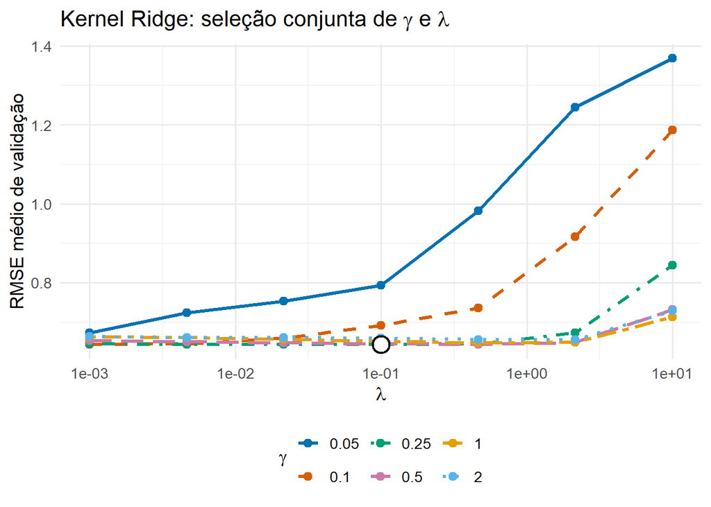

```r
# Garantir que gamma seja tratado como variável categórica
resultados_krr_plot <-
  resultados_krr |>
  mutate(
    gamma_f = factor(
      gamma,
      levels = sort(unique(gamma))
    )
  )

ggplot(
  resultados_krr_plot,
  aes(
    x = lambda,
    y = rmse_cv,
    color = gamma_f,
    linetype = gamma_f,
    group = gamma_f
  )
) +
  geom_line(linewidth = 1.1) +
  geom_point(size = 2.5) +
  geom_point(
  data = melhor_krr,
  aes(
    x = lambda,
    y = rmse_cv
  ),
  inherit.aes = FALSE,
  shape = 21,
  size = 5,
  stroke = 1.3,
  fill = "white"
) +
  scale_x_log10() +
  scale_color_manual(
    values = c(
      "#0072B2",
      "#D55E00",
      "#009E73",
      "#CC79A7",
      "#E69F00",
      "#56B4E9"
    )
  ) +
  scale_linetype_manual(
    values = c(
      "solid",
      "dashed",
      "dotdash",
      "longdash",
      "twodash",
      "dotted"
    )
  ) +
  labs(
    x = expression(lambda),
    y = "RMSE médio de validação",
    color = expression(gamma),
    linetype = expression(gamma),
    title = expression(
      "Kernel Ridge: seleção conjunta de " * gamma * " e " * lambda
    )
  ) +
  theme_minimal(base_size = 13) +
  theme(
    legend.position = "bottom"
  )
```

**O que observar?**

Cada curva representa um valor de $\gamma$, enquanto o eixo horizontal representa diferentes valores de regularização $\lambda$.

Assim, a validação cruzada não seleciona $\gamma$ e $\lambda$ separadamente. Ela procura a combinação

$$(\gamma^\ast,\lambda^\ast)
=
\arg\min_{\gamma,\lambda}
\widehat R_{CV}(\gamma,\lambda)$$

Entre as combinações avaliadas, o ponto destacado corresponde ao menor RMSE médio de validação.

Os dois hiperparâmetros exercem papéis diferentes: $\gamma$ controla a **escala de similaridade do kernel RBF**, enquanto $\lambda$ controla a **intensidade da regularização**.

O gráfico permite observar que a qualidade do modelo depende da **combinação** entre a escala de similaridade do kernel e a intensidade da regularização.

Uma combinação inadequada pode produzir tanto um modelo excessivamente flexível quanto excessivamente rígido.

# 24 Finalmente: o conjunto de teste

Somente agora utilizaremos o conjunto de teste.

Os hiperparâmetros já foram escolhidos utilizando apenas o conjunto de treinamento.

### Regressão linear

```r
pred_teste_lm <-
  predict(
    ajuste_lm,
    new_data = teste
  ) |>
  bind_cols(
    teste |> select(y)
  )

rmse_lm <-
  pred_teste_lm |>
  rmse(
    truth = y,
    estimate = .pred
  )

rmse_lm
```

```
# A tibble: 1 × 3
  .metric .estimator .estimate
  <chr>   <chr>          <dbl>
1 rmse    standard        1.56
```

### KNN final

```r
wf_knn_final <-
  finalize_workflow(
    wf_knn,
    melhor_knn
  )

ajuste_knn_final <-
  fit(
    wf_knn_final,
    data = treino
  )

pred_teste_knn <-
  predict(
    ajuste_knn_final,
    new_data = teste
  ) |>
  bind_cols(
    teste |> select(y)
  )

rmse_knn <-
  pred_teste_knn |>
  rmse(
    truth = y,
    estimate = .pred
  )

rmse_knn
```

```
# A tibble: 1 × 3
  .metric .estimator .estimate
  <chr>   <chr>          <dbl>
1 rmse    standard       0.628
```

### Nadaraya–Watson final

```r
pred_teste_nw <-
  nw_gauss(
    treino$x,
    treino$y,
    teste$x,
    melhor_h$h
  )

rmse_nw <-
  sqrt(
    mean(
      (teste$y - pred_teste_nw)^2
    )
  )

rmse_nw
```

```
[1] 0.6233488
```

### Kernel Ridge final

```r
ajuste_krr_final <-
  ajustar_krr(
    X = treino |> select(x),
    y = treino$y,
    gamma = melhor_krr$gamma,
    lambda = melhor_krr$lambda
  )

pred_teste_krr <-
  predizer_krr(
    ajuste_krr_final,
    teste |> select(x)
  )

rmse_krr <-
  sqrt(
    mean(
      (teste$y - pred_teste_krr)^2
    )
  )

rmse_krr
```

```
[1] 0.6060287
```

# 25 Comparação final

```r
comparacao_final <-
  tibble(
    metodo = c(
      "Regressão linear",
      "KNN",
      "Nadaraya-Watson",
      "Kernel Ridge"
    ),
    RMSE = c(
      rmse_lm$.estimate,
      rmse_knn$.estimate,
      rmse_nw,
      rmse_krr
    )
  ) |>
  arrange(RMSE)

comparacao_final
```

```
# A tibble: 4 × 2
  metodo            RMSE
  <chr>            <dbl>
1 Kernel Ridge     0.606
2 Nadaraya-Watson  0.623
3 KNN              0.628
4 Regressão linear 1.56
```

O objetivo dessa tabela não é concluir que o método com menor RMSE será sempre superior.

Ela responde apenas:

> Para este problema, com estas escolhas feitas previamente por validação, qual foi o desempenho em observações que não participaram da seleção dos modelos?

# 26 O que o teste responde?

O teste **não responde**:

> Qual $k$, $h$, $\sigma$ ou $\lambda$ devo escolher?

Essas perguntas já foram respondidas pela validação cruzada.

O teste responde:

> Depois de realizar todas as escolhas usando os dados de treinamento, qual é o desempenho do procedimento em novas observações?

Essa distinção continua sendo fundamental.

# 27 Fluxo correto de modelagem

O procedimento pode ser resumido como:

$$\text{Dados}
\rightarrow
\begin{cases}
\text{Treino}\\
\text{Teste}
\end{cases}$$

Dentro do treinamento:

$$\text{Treino}
\rightarrow
\text{validação cruzada}
\rightarrow
\text{hiperparâmetros}^{\ast}
\rightarrow
\text{modelo final}$$

Somente depois:

$$\text{Modelo final}
+
\text{Teste}
\rightarrow
\text{estimativa final de generalização}$$

Em particular,

$$\text{seleção de hiperparâmetros}
\neq
\text{avaliação final no teste}$$

Esse fluxo será central na **Atividade Avaliativa 2**.